# Homework 3

Answer Key

ECON 315 — Spring 2021

# Concepts and Critical Thinking

## Question 1

#### Explain the elements of a tort that a Plaintiff must demonstrate in court in order to collect damages under (i) a strict liability rule, and (2) a negligence rule.

Under **strict liability**, a Plaintiff must merely demonstrate: 1. Plaintiff suffered some harm 2. Defendant caused that harm

Under **negligence**, a Plaintiff must demonstrate: 1. Plaintiff suffered some harm 2. Defendant caused that harm 3. Defendant breached a legal duty (was negligent, or at fault)

## Question 2

#### Under each of the following liability rules, what amount of precaution will the Injurer (Defendant) and Victim (Plaintiff) choose to take in advance?

1. No liability
2. Strict liability
3. Negligence (assuming the legal standard is set to the efficient level)

#### You may wish to make a table, but you must briefly explain the reasoning behind each cell.

Using our economic model of precaution, we need to consider three components of the cost of accidents:

1. The cost of precaution $(wx)$
2. The expected cost of an accident $p(x)A$
3. The total social cost $p(x)A+wx$

The efficient amount of injurer precaution minimizes the total social cost $p(x)A+wx$, and efficient victim precaution minimizes total social cost $p(y)A+wy$ $(x$ is the level of *injurer* precaution, $y$ is the level of *victim* precaution).

| Rule | Injurer Precaution | Victim Precaution |
| --- | --- | --- |
| No liability | None | Efficient $(y^\star)$ |
| Strict liability | Efficient $(x^\star)$ | None |
| Negligence | Efficient $(x^\star)$ | Efficient $(y^\star)$ |

Under **no liability**, the injurer is not liable for any accident (so does not face the expected cost of an accident $p(x)A)$, and only incurs the cost of their precaution $(wx)$, which they will minimize, by taking *no* precaution.

The victim thus bears the entire social cost of the accident $p(y)A+wy$. They will minimize this at $y^star$, the efficient level of precaution.

Under **strict liability**, the injurer bears the entire social cost of the accident $p(x)A+wx$, which they will minimize at $x^\star$, the efficient level of precaution.

The victim is not liable for any accident (so does not face the expected cost of the accident $p(y)A)$, and only incurs the cost of their precaution $(wy)$, which they will minimize, by taking *no* precaution.

Under **negligence**, the injurer is liable and bears the entire social cost of the accident $p(x)A+wx$ only if they take *less than the legal standard level of caution*, if they take more than the legal standard, they only incur the cost of their precaution $(wx)$. They will thus minimize the costs they face by taking the legal standard of caution, which, if set properly, is the efficient level of precaution, $x^\star$.

Since the injurer will take efficient precaution and avoid liability, the victim bears the residual risk of an accident, facing the full social cost $p(y)A+wy$, which they will minimize at $y^\star$, the efficient level of precaution.

## Question 3

#### Explain the following types of negligence rules (when would Defendant win a case, and when would Plaintiff win a case):

> 1. Negligence
> 2. Strict liability with a defense of contributory negligence
> 3. Negligence with a defense of contributory negligence
> 4. Comparative negligence

Under a **negligence** rule, Plantiff would win if Defendant was negligent, i.e., did not exercise due care (the legal standard of precaution). The Defendant would win if they were not negligent, i.e. did exercise due care.

Under **strict liability with a defense of contributory negligence**, Plaintiff would win if they were not negligent. Defendant would win if Plaintiff was negligent.

Under **negligence with a defense of contributory negligence**, Plaintiff would win if they were not negligent and Defendant was negligent. Defendant would win if they were not negligent and Plaintiff was negligent.

Under **comparative negligence**, Plaintiff would win if they were not negligent and Defendant was negligent. Defendant would win if they were not negligent and Plaintiff was negligent. If both are found negligent, the parties share liability in proportion to their negligence.

## Question 4

#### Briefly give some economic reasons why strict liability may make the most sense as a rule for products liability.

In general, if it is too difficult for a victim to recover damages against an injurer (that legitimately caused them harm), then their “getting away with it” lowers the expected cost of an accident to injurers, causing them to take less than efficient precaution. It is much harder to prove a manufacturer was negligent than to simply prove that they caused an accident that harmed a consumer, which is all that would be required under a strict liability rule.

Additionally, as manufacturers are unable to monitor whether consumers use their product safely, and if consumers mispercieve the riskiness of a product, consumers are more likely to use the product negligently and cause an accident. Manufacturers are much more knowledgeable about the risks of their product, and have greater control over how safe the product is when used. Only under a rule of strict liability do these additional problems not cause more accidents, as manufacturers face strong incentives to take efficient precaution and make products safer.

# Problems

## Question 5

Consider a barge owner who is deciding whether to post an attendant on his barge to make sure that it remains properly moored to the pier. The following table gives the total cost of hiring the attendant, the probability of an accident, and the fixed cost of an accident:

| Choice | Cost of Caution | Accident Probability | Damages |
| --- | --- | --- | --- |
| No attendant | $0 | 0.25 | $400 |
| Attendant posted for 24 hours | $95 | 0.00 | $400 |

### Part A

#### Calculate the marginal cost and marginal benefit[^1] of posting the attendant for 24 hours. According to the Hand rule (interpreted on the margin as marginal cost and marginal benefit), would the barge owner be found negligent for failing to post an attendant?

The Hand rule, using Judge Learned Hand’s notation, is that an injurer should be found negligent if:

$$B < pL$$

Where $B$ is the “burden” or cost of precaution, $p$ is the probability of an accident, and $L$ is the “liability” or harm/damages caused by the accident. If this equation is true, it would be efficient for an injurer to invest in *more* precaution, as the total benefits exceed the total costs.

In our *marginalist* interpretation of the hand rule, an injurer should be found negligent if:

$$w<-p'(x)A$$
that is to say, if the marginal cost of precaution $w$ is less than the marginal benefit of a reduction in expected cost of an accident.

Here, the marginal cost of precaution — posting an attendant for 24 hours — is $95. The marginal benefit is the reduction in expected cost of the accident $(0.25-0.0) \times 400$, or $100. Since the marginal cost of $95 is less than the marginal benefit of $100, the injurer should be found negligent, as taking the precaution is efficient.

### Part B

#### Now suppose that the barge owner’s options instead are to not post an attendant, or to post the attendant only during the day (12 hours).

| Choice | Cost of Caution | Accident Probability | Damages |
| --- | --- | --- | --- |
| No attendant | $0 | 0.25 | $400 |
| Attendant posted for 12 hours | $50 | 0.10 | $400 |

#### According to the Hand rule, would the barge owner be found negligent for failing to post an attendant during the day?

Here, the marginal cost of precaution — posting an attendant for 12 hours — is $50. The marginal benefit is the reduction in expected cost of the accident $(0.25-0.10) \times 400$, or $60. Since the marginal cost of $50 is less than the marginal benefit of $60, the injurer should be found negligent, as taking the precaution is efficient.

### Part C

#### Suppose prior to the accident, the barge owner had posted an attendant during the day. Suppose the victim claims that the owner was negligent for not having posted the attendant for 24 hours. Use the Hand rule (on the margin) to evaluate the merits of this claim.

The plaintiff’s claim in this case is that the defendant should be found negligent for failing to post an attendant for 24 hours rather than only 12 hours during the day. The marginal cost of hiring an attendant for the additional time is $95-50=45$, while the marginal reduction in expected damages is $(0.10-0.00) \times (400) = 40$. Since the marginal cost of $45 is higher than the marginal benefit of $40, the injurer should *not* be found negligent under this claim, as taking the increased precaution (of having the 12 hour attendant stay for 24 hours) is inefficient.

### Part D

#### For each of the three options: (i) no attendant (ii) attendant during the day (iii) attendant for 24 hours, calculate *total* expected costs (costs of precaution plus expected damages). Which option minimizes total costs? Reconcile the result with your answers to parts A-C.

Total expected accident costs $(B+PL)$ are as follows:

[output not shown]

Costs are therefore minimized when an attendant is only posted during the day. Parts (a) – (c) showed that the marginal Hand rule produces the cost-minimizing result when the three options are compared in a pairwise manner. Specifically, we saw that it is cheaper to hire an attendant for 24 hours rather than not at all, but hiring an attendant only for the day is cheaper still.

## Question 6

The (inverse) demand curve for a product is

$$p=100-q$$

Suppose the marginal cost of producing the product is $5.

### Part A

#### Find the equilibrium output and price for the product.

This simply is setting demand equal to supply:

$$\begin{align*}
a-b(q)&=c\\
100-q&=5\\
q^\star &=95\\
\\ \end{align*}$$

Plug quantity into either demand or supply to get the price. Since supply is a constant marginal cost (i.e. a horizontal line), the price will always be the seller’s marginal cost:

$$\begin{align*}
p^*&=c\\
p^*&=5\\
\\ \end{align*}$$

#### For the remaining parts of this question, suppose there is a 5% chance that the product will cause $1,000 worth of damages in an accident.

### Part B

#### What is the equilibrium output and price for the product under a rule of no liability $(s=0)$?

Now add the risk of an accident $(pD)$ to both the demand and supply, allocated by $s$. If consumers bear any risk $(s=0)$, which they do here, this will decrease demand since they are willing to pay less for the riskier product.

$$\begin{align*}
a-b(q)-(1-s)pD&=c+spD \\
100-q-(1)(0.05)(1,000)&= 5 + (0)(0.05)(1,000)\\
100-q-50 &=5 \\
50-q &= 5 \\
q^{\star \star} &= 45 \\ \end{align*}$$

$$\begin{align*}
p_{NL} &= c \\
p_{NL} &= 5 \\
\\ \end{align*}$$

### Part C

#### What is the equilibrium output and price for the product under a rule of strict liability $(s=1)$?

Now add the risk of an accident $(pD)$ to both the demand and supply, allocated by $s$. If producers bear any risk $(s=1)$, which they do here, this will decrease supply since they must ask for a higher price to sell the riskier product (for which they are liable).

$$\begin{align*}
a-b(q)-(1-s)pD&=c+spD \\
100-q-(0)(0.05)(1,000)&= 5 + (1)(0.05)(1,000)\\
100-q &=5 + 50\\
100-q &= 55 \\
q^{\star \star} &= 45 \\ \end{align*}$$

$$\begin{align*}
p_{SL} &= c + spD\\
p_{SL} &= 5 +(1)(0.05)(1,000) \\
p_{SL} &= 5 + 50\\
p_{SL} &= 55\\
\\ \end{align*}$$

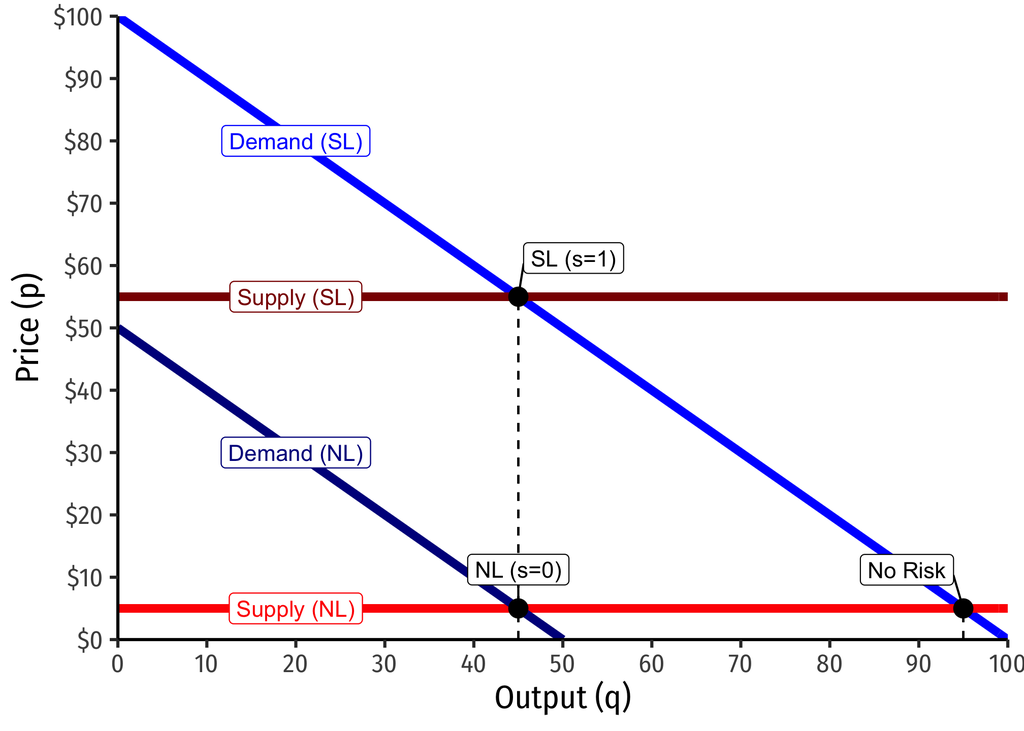

### Part D

#### Suppose the liability rule is no liability, and consumers *underestimate* the riskiness of the product, believing the probability of the accident is 2.5% ($\alpha = 0.5)$. Derive the equilibrium output and price for the product.

Regardless, now we are simply altering the probability in the risk term on the demand side. I will use $\alpha$ and the original probability:

$$\begin{align*}
a-b(q)-(1-s)\alpha pD&=c+spD \\
100-q-(1)(0.5)(0.05)(1,000)&= 5 + (0)(0.05)(1,000)\\
100-q -25 &=5\\
75-q &= 5 \\
q_{under} &= 70 \\ \end{align*}$$

Price remains $c=5$. Because consumers *under*estimate the riskiness of the product, they demand *more* than the efficient quantity $(q^{\star \star}$ of 45).

### Part E

#### Suppose instead consumers *overestimate* the riskiness of the product, believing the probability of the accident is 7.5% ($\alpha = 1.50)$. Derive the equilibrium output and price for the product.

Same as for the previous question, I will use $\alpha$ and the original probability to adjust the risk on the demand side:

$$\begin{align*}
a-b(q)-(1-s)\alpha pD&=c+spD \\
100-q-(1)(1.5)(0.05)(1,000)&= 5 + (0)(0.05)(1,000)\\
100-q -75 &=5\\
25-q &= 5 \\
q_{over} &= 20 \\ \end{align*}$$

Price remains $c=5$. Because consumers *over*estimate the riskiness of the product, they demand *less* than the efficient quantity $(q^{\star \star}$ of 45).

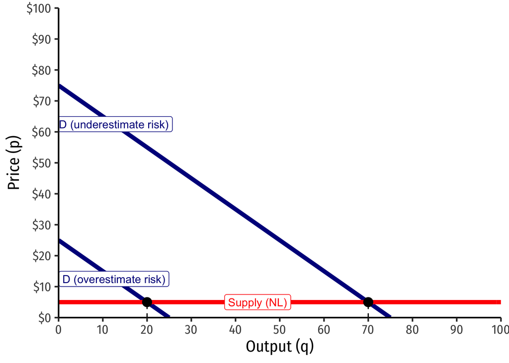

# Concepts and Critical Thinking

## Question 1

#### Explain the elements of a tort that a Plaintiff must demonstrate in court in order to collect damages under (i) a strict liability rule, and (2) a negligence rule.

Under **strict liability**, a Plaintiff must merely demonstrate: 1. Plaintiff suffered some harm 2. Defendant caused that harm

Under **negligence**, a Plaintiff must demonstrate: 1. Plaintiff suffered some harm 2. Defendant caused that harm 3. Defendant breached a legal duty (was negligent, or at fault)

## Question 2

#### Under each of the following liability rules, what amount of precaution will the Injurer (Defendant) and Victim (Plaintiff) choose to take in advance?

1. No liability
2. Strict liability
3. Negligence (assuming the legal standard is set to the efficient level)

#### You may wish to make a table, but you must briefly explain the reasoning behind each cell.

Using our economic model of precaution, we need to consider three components of the cost of accidents:

1. The cost of precaution $(wx)$
2. The expected cost of an accident $p(x)A$
3. The total social cost $p(x)A+wx$

The efficient amount of injurer precaution minimizes the total social cost $p(x)A+wx$, and efficient victim precaution minimizes total social cost $p(y)A+wy$ $(x$ is the level of *injurer* precaution, $y$ is the level of *victim* precaution).

| Rule | Injurer Precaution | Victim Precaution |
| --- | --- | --- |
| No liability | None | Efficient $(y^\star)$ |
| Strict liability | Efficient $(x^\star)$ | None |
| Negligence | Efficient $(x^\star)$ | Efficient $(y^\star)$ |

Under **no liability**, the injurer is not liable for any accident (so does not face the expected cost of an accident $p(x)A)$, and only incurs the cost of their precaution $(wx)$, which they will minimize, by taking *no* precaution.

The victim thus bears the entire social cost of the accident $p(y)A+wy$. They will minimize this at $y^star$, the efficient level of precaution.

Under **strict liability**, the injurer bears the entire social cost of the accident $p(x)A+wx$, which they will minimize at $x^\star$, the efficient level of precaution.

The victim is not liable for any accident (so does not face the expected cost of the accident $p(y)A)$, and only incurs the cost of their precaution $(wy)$, which they will minimize, by taking *no* precaution.

Under **negligence**, the injurer is liable and bears the entire social cost of the accident $p(x)A+wx$ only if they take *less than the legal standard level of caution*, if they take more than the legal standard, they only incur the cost of their precaution $(wx)$. They will thus minimize the costs they face by taking the legal standard of caution, which, if set properly, is the efficient level of precaution, $x^\star$.

Since the injurer will take efficient precaution and avoid liability, the victim bears the residual risk of an accident, facing the full social cost $p(y)A+wy$, which they will minimize at $y^\star$, the efficient level of precaution.

## Question 3

#### Explain the following types of negligence rules (when would Defendant win a case, and when would Plaintiff win a case):

> 1. Negligence
> 2. Strict liability with a defense of contributory negligence
> 3. Negligence with a defense of contributory negligence
> 4. Comparative negligence

Under a **negligence** rule, Plantiff would win if Defendant was negligent, i.e., did not exercise due care (the legal standard of precaution). The Defendant would win if they were not negligent, i.e. did exercise due care.

Under **strict liability with a defense of contributory negligence**, Plaintiff would win if they were not negligent. Defendant would win if Plaintiff was negligent.

Under **negligence with a defense of contributory negligence**, Plaintiff would win if they were not negligent and Defendant was negligent. Defendant would win if they were not negligent and Plaintiff was negligent.

Under **comparative negligence**, Plaintiff would win if they were not negligent and Defendant was negligent. Defendant would win if they were not negligent and Plaintiff was negligent. If both are found negligent, the parties share liability in proportion to their negligence.

## Question 4

#### Briefly give some economic reasons why strict liability may make the most sense as a rule for products liability.

In general, if it is too difficult for a victim to recover damages against an injurer (that legitimately caused them harm), then their “getting away with it” lowers the expected cost of an accident to injurers, causing them to take less than efficient precaution. It is much harder to prove a manufacturer was negligent than to simply prove that they caused an accident that harmed a consumer, which is all that would be required under a strict liability rule.

Additionally, as manufacturers are unable to monitor whether consumers use their product safely, and if consumers mispercieve the riskiness of a product, consumers are more likely to use the product negligently and cause an accident. Manufacturers are much more knowledgeable about the risks of their product, and have greater control over how safe the product is when used. Only under a rule of strict liability do these additional problems not cause more accidents, as manufacturers face strong incentives to take efficient precaution and make products safer.

# Problems

## Question 5

Consider a barge owner who is deciding whether to post an attendant on his barge to make sure that it remains properly moored to the pier. The following table gives the total cost of hiring the attendant, the probability of an accident, and the fixed cost of an accident:

| Choice | Cost of Caution | Accident Probability | Damages |
| --- | --- | --- | --- |
| No attendant | $0 | 0.25 | $400 |
| Attendant posted for 24 hours | $95 | 0.00 | $400 |

### Part A

#### Calculate the marginal cost and marginal benefit[^2] of posting the attendant for 24 hours. According to the Hand rule (interpreted on the margin as marginal cost and marginal benefit), would the barge owner be found negligent for failing to post an attendant?

The Hand rule, using Judge Learned Hand’s notation, is that an injurer should be found negligent if:

$$B < pL$$

Where $B$ is the “burden” or cost of precaution, $p$ is the probability of an accident, and $L$ is the “liability” or harm/damages caused by the accident. If this equation is true, it would be efficient for an injurer to invest in *more* precaution, as the total benefits exceed the total costs.

In our *marginalist* interpretation of the hand rule, an injurer should be found negligent if:

$$w<-p'(x)A$$
that is to say, if the marginal cost of precaution $w$ is less than the marginal benefit of a reduction in expected cost of an accident.

Here, the marginal cost of precaution — posting an attendant for 24 hours — is $95. The marginal benefit is the reduction in expected cost of the accident $(0.25-0.0) \times 400$, or $100. Since the marginal cost of $95 is less than the marginal benefit of $100, the injurer should be found negligent, as taking the precaution is efficient.

### Part B

#### Now suppose that the barge owner’s options instead are to not post an attendant, or to post the attendant only during the day (12 hours).

| Choice | Cost of Caution | Accident Probability | Damages |
| --- | --- | --- | --- |
| No attendant | $0 | 0.25 | $400 |
| Attendant posted for 12 hours | $50 | 0.10 | $400 |

#### According to the Hand rule, would the barge owner be found negligent for failing to post an attendant during the day?

Here, the marginal cost of precaution — posting an attendant for 12 hours — is $50. The marginal benefit is the reduction in expected cost of the accident $(0.25-0.10) \times 400$, or $60. Since the marginal cost of $50 is less than the marginal benefit of $60, the injurer should be found negligent, as taking the precaution is efficient.

### Part C

#### Suppose prior to the accident, the barge owner had posted an attendant during the day. Suppose the victim claims that the owner was negligent for not having posted the attendant for 24 hours. Use the Hand rule (on the margin) to evaluate the merits of this claim.

The plaintiff’s claim in this case is that the defendant should be found negligent for failing to post an attendant for 24 hours rather than only 12 hours during the day. The marginal cost of hiring an attendant for the additional time is $95-50=45$, while the marginal reduction in expected damages is $(0.10-0.00) \times (400) = 40$. Since the marginal cost of $45 is higher than the marginal benefit of $40, the injurer should *not* be found negligent under this claim, as taking the increased precaution (of having the 12 hour attendant stay for 24 hours) is inefficient.

### Part D

#### For each of the three options: (i) no attendant (ii) attendant during the day (iii) attendant for 24 hours, calculate *total* expected costs (costs of precaution plus expected damages). Which option minimizes total costs? Reconcile the result with your answers to parts A-C.

Total expected accident costs $(B+PL)$ are as follows:

[output not shown]

Costs are therefore minimized when an attendant is only posted during the day. Parts (a) – (c) showed that the marginal Hand rule produces the cost-minimizing result when the three options are compared in a pairwise manner. Specifically, we saw that it is cheaper to hire an attendant for 24 hours rather than not at all, but hiring an attendant only for the day is cheaper still.

## Question 6

The (inverse) demand curve for a product is

$$p=100-q$$

Suppose the marginal cost of producing the product is $5.

### Part A

#### Find the equilibrium output and price for the product.

This simply is setting demand equal to supply:

$$\begin{align*}
a-b(q)&=c\\
100-q&=5\\
q^\star &=95\\
\\ \end{align*}$$

Plug quantity into either demand or supply to get the price. Since supply is a constant marginal cost (i.e. a horizontal line), the price will always be the seller’s marginal cost:

$$\begin{align*}
p^*&=c\\
p^*&=5\\
\\ \end{align*}$$

#### For the remaining parts of this question, suppose there is a 5% chance that the product will cause $1,000 worth of damages in an accident.

### Part B

#### What is the equilibrium output and price for the product under a rule of no liability $(s=0)$?

Now add the risk of an accident $(pD)$ to both the demand and supply, allocated by $s$. If consumers bear any risk $(s=0)$, which they do here, this will decrease demand since they are willing to pay less for the riskier product.

$$\begin{align*}
a-b(q)-(1-s)pD&=c+spD \\
100-q-(1)(0.05)(1,000)&= 5 + (0)(0.05)(1,000)\\
100-q-50 &=5 \\
50-q &= 5 \\
q^{\star \star} &= 45 \\ \end{align*}$$

$$\begin{align*}
p_{NL} &= c \\
p_{NL} &= 5 \\
\\ \end{align*}$$

### Part C

#### What is the equilibrium output and price for the product under a rule of strict liability $(s=1)$?

Now add the risk of an accident $(pD)$ to both the demand and supply, allocated by $s$. If producers bear any risk $(s=1)$, which they do here, this will decrease supply since they must ask for a higher price to sell the riskier product (for which they are liable).

$$\begin{align*}
a-b(q)-(1-s)pD&=c+spD \\
100-q-(0)(0.05)(1,000)&= 5 + (1)(0.05)(1,000)\\
100-q &=5 + 50\\
100-q &= 55 \\
q^{\star \star} &= 45 \\ \end{align*}$$

$$\begin{align*}
p_{SL} &= c + spD\\
p_{SL} &= 5 +(1)(0.05)(1,000) \\
p_{SL} &= 5 + 50\\
p_{SL} &= 55\\
\\ \end{align*}$$

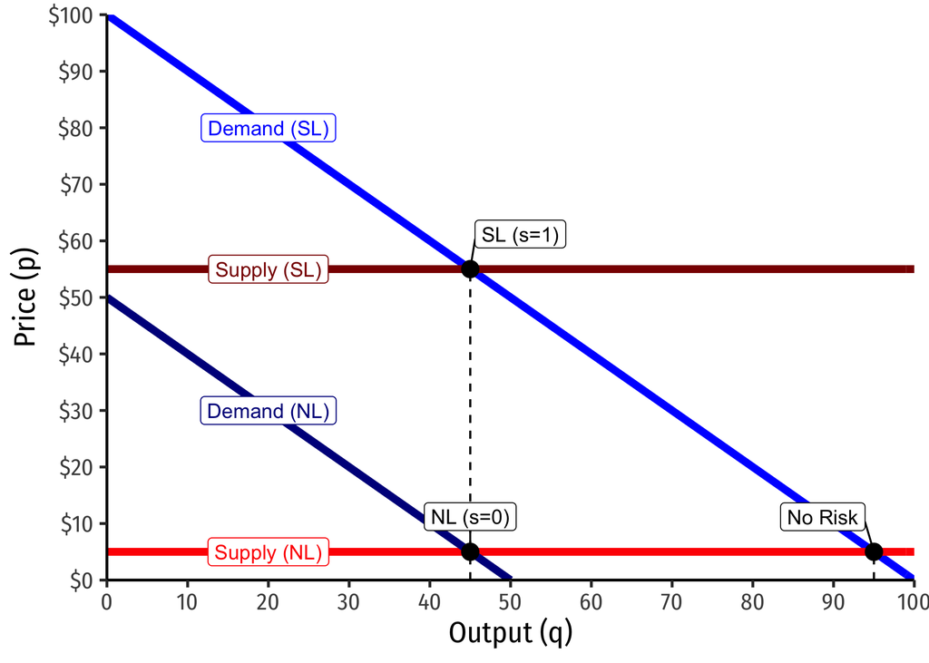

### Part D

#### Suppose the liability rule is no liability, and consumers *underestimate* the riskiness of the product, believing the probability of the accident is 2.5% ($\alpha = 0.5)$. Derive the equilibrium output and price for the product.

Regardless, now we are simply altering the probability in the risk term on the demand side. I will use $\alpha$ and the original probability:

$$\begin{align*}
a-b(q)-(1-s)\alpha pD&=c+spD \\
100-q-(1)(0.5)(0.05)(1,000)&= 5 + (0)(0.05)(1,000)\\
100-q -25 &=5\\
75-q &= 5 \\
q_{under} &= 70 \\ \end{align*}$$

Price remains $c=5$. Because consumers *under*estimate the riskiness of the product, they demand *more* than the efficient quantity $(q^{\star \star}$ of 45).

### Part E

#### Suppose instead consumers *overestimate* the riskiness of the product, believing the probability of the accident is 7.5% ($\alpha = 1.50)$. Derive the equilibrium output and price for the product.

Same as for the previous question, I will use $\alpha$ and the original probability to adjust the risk on the demand side:

$$\begin{align*}
a-b(q)-(1-s)\alpha pD&=c+spD \\
100-q-(1)(1.5)(0.05)(1,000)&= 5 + (0)(0.05)(1,000)\\
100-q -75 &=5\\
25-q &= 5 \\
q_{over} &= 20 \\ \end{align*}$$

Price remains $c=5$. Because consumers *over*estimate the riskiness of the product, they demand *less* than the efficient quantity $(q^{\star \star}$ of 45).

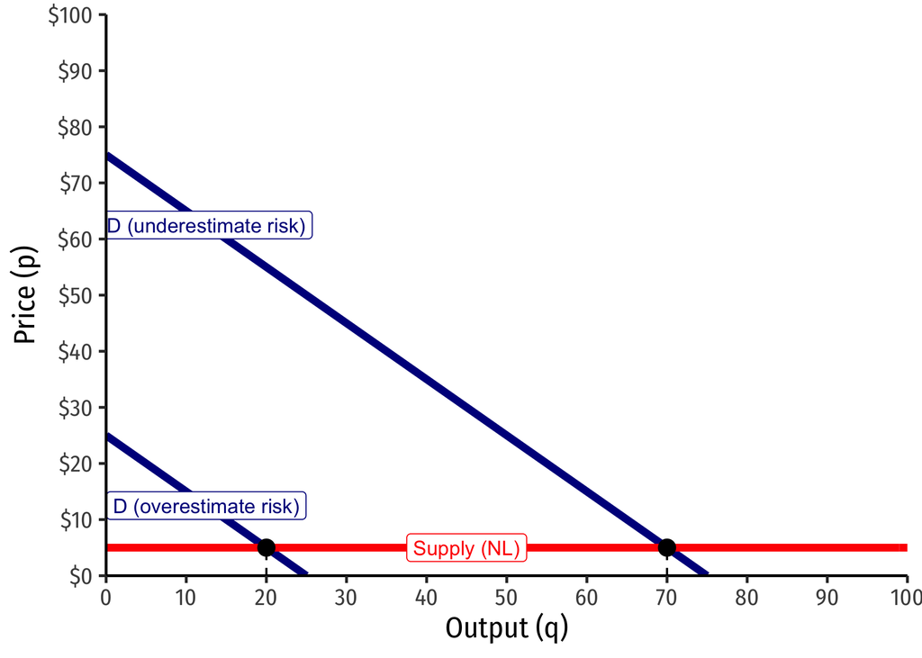

[^1]: Hint: interpret the *change* in expected cost of an accident.
[^2]: Hint: interpret the *change* in expected cost of an accident.